# SRM Chapter 6.3

theBudgetActuary

# Principal Component Analysis

In the past two sections we talked about the two unsupervised learning methods of K-means and hierarchical clustering, which are two methods to cluster our data into groups based off similarity.

In this section we talk about another unsupervised learning method, Principal Component Analysis. PCA is not a clustering technique, instead it is a dimension reduction technique. Dimension reduction means transforming the old features into a new set of features.

# Goals of PCA

1. **Identify Hidden Patterns**

Traditional plots generally allow us to view two variables at time, or if we make 3-d plots up to three variables at a time. When we have more than three variables we lose our ability to view all our data at one time. PCA creates a new set of features from our old features which allows us to crunch the important parts of our data together in order to view the most variation (information) from our data in just a couple variables.

2. **Reduce the Dimensionality of the Data**

PCA can remove noise and redundancy in our data allowing not only easier interpretation, but can also be paired with supervised learning algorithms in order to achieve more accurate results.

3. **Identify Correlated Variables**

When performing correlation analysis the correlation statistic finds the correlation between two variables at a time. With PCA the correlation among groups of variables can be plotted together to see how they relate to each other. (Kassambara, 2017)

# Loadings

Principal components are made up of linear combinations of the original variables. These linear combinations are found using what are called ‘loadings’.

In the first principal component, PC1, the loadings are chosen to find the linear combinations among the original variables that account for as much of the variation as possible, with the constraint that the sum of squared loadings is equal to one. This constraint is needed so that there is a unique solution. The number of loadings for each PC will be equal to the number of variables in the original data set. The loadings for one PC form the loading vector. The loading vector can be defined in two ways:

1. The loading vector represents the line where the observations are close as possible to the original observations.
2. The loading vector represents the lines along which the data varies the most. (Kassambara, 2017)

The subsequent principal components all choose their loadings to find the linear combinations of original variables that account for as much of the remaining variation as possible. Again, the sum of squared loadings must add to one. All principal components must also be uncorrelated with the previous principal components. (James et al.)

**Constraints:**

Sum of squared loadings for each PC must equal 1:

$\sum_{j=1}^{p} \phi^{2}_{j,m}=1$

$\phi_{j,m}$- Loading for variable j, PC m

Correlation between PC’s is 0:

$\sum_{j=1}^{p} \phi_{j,m}*\phi_{j,u}=0$

Loadings from Iris Dataset

|  | PC1 | PC2 | PC3 |
| --- | --- | --- | --- |
| Sepal.Length | 0.7024042 | -0.0379622 | -0.7107653 |
| Sepal.Width | 0.6764112 | -0.2752564 | 0.6831557 |
| Petal.Length | 0.2215768 | 0.9606210 | 0.1676632 |

# Scores

If we use our loadings and solve for our linear formula for each observation, the output will be our ‘scores’. If there are an equal number of principal components to the number of original variables there will be an equal number of scores to the original number of observations.

These scores will capture the maximum possible value for the remaining sample variance in each principal component.

$z_{i,m}=\sum_{j=1}^{p} \phi_{j,m}x_{i,j}$

$z_{i,m}$- PC score for observation i, PC m

First 15 Scores for the 3 PC’s

| PC1 | PC2 | PC3 |
| --- | --- | --- |
| 0.1330414 | -0.3775580 | -0.0911961 |
| -1.1920251 | 0.0247548 | -0.6450815 |
| -1.3338331 | -0.6647791 | 0.0286879 |
| -1.4578329 | 0.5378999 | 0.2304519 |
| 0.1264872 | -0.4433434 | 0.2943811 |
| 1.8507611 | 0.9598039 | 0.3692667 |
| -1.0242649 | -0.2488705 | 0.7009413 |
| -0.1196582 | 0.2671579 | 0.0131831 |
| -2.3493313 | 0.1534423 | 0.1470558 |
| -0.8759027 | 0.5064488 | -0.3584053 |
| 1.2185164 | -0.0035841 | -0.2040857 |
| -0.3789120 | 0.8460883 | 0.5031394 |
| -1.3860018 | 0.0352385 | -0.4487958 |
| -2.7419846 | -1.5862324 | 0.2404785 |
| 2.1705920 | -1.9482154 | -0.7135089 |

# Choosing the Number of Principal Compenents

The maximum number of principal components created is either the number of variables in the original data set, or the number of observations minus one. If there are near perfect correlations present in the data it is possible there will be less principal components than there were variables in the original data set.

-m The number of variables in original data set

-n The number of observations in original data set

PCA is most effective when a large portion of the variance (information), can be captured in the first few principal components. This occurs when there are existent linear combinations, or correlations, that exist within the data. Since correlation among variables represents redundant information, when there exists multicollinearity within the data PCA would be able to represent the data in a fewer number of dimensions, allowing to capture a large portion of the total variation in the first few PC’s.

If there is no multicollinearity present in the data it would take nearly all, if not all of the principal components in order to explain a sufficient amount of information. In this case PCA would not be the best option.

If we included more PC’s in our analysis we lose interpretation, but are able to account for more information from the original data set. If we include less PC’s we include less of the original data set variation, but it is more interpretable.

A considerable amount of variation can be arbitrary, one way to choose is to use a scree plot. A scree plot puts the PC’s on the x-axis and the variance explained on the y-axis. The number of PC’s can be chosen where there is a substantial decrease in the cumulative percentage of variance explained for an additional PC.

In the scree plot below two PC’s explain about 90% of the information which would probably be an acceptable number of principal components.

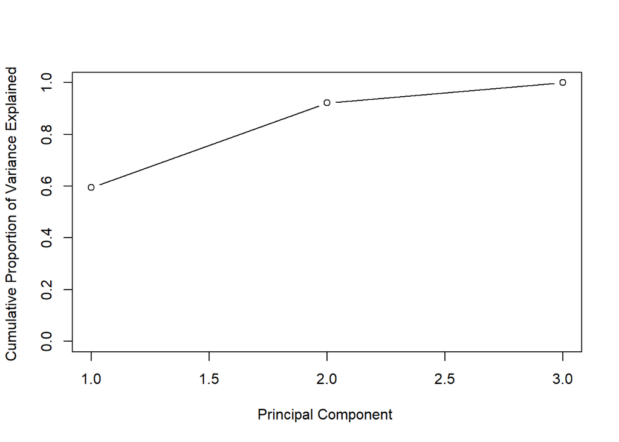

# Biplot

A biplot is how we will plot our PC’s in order to obtain information from more than three variables at a time. Length of arrows represent the correlation of the original variable with the PC scores. The variable names represent the loadings of the PC’s. The individual observations represent the scores of the observations.

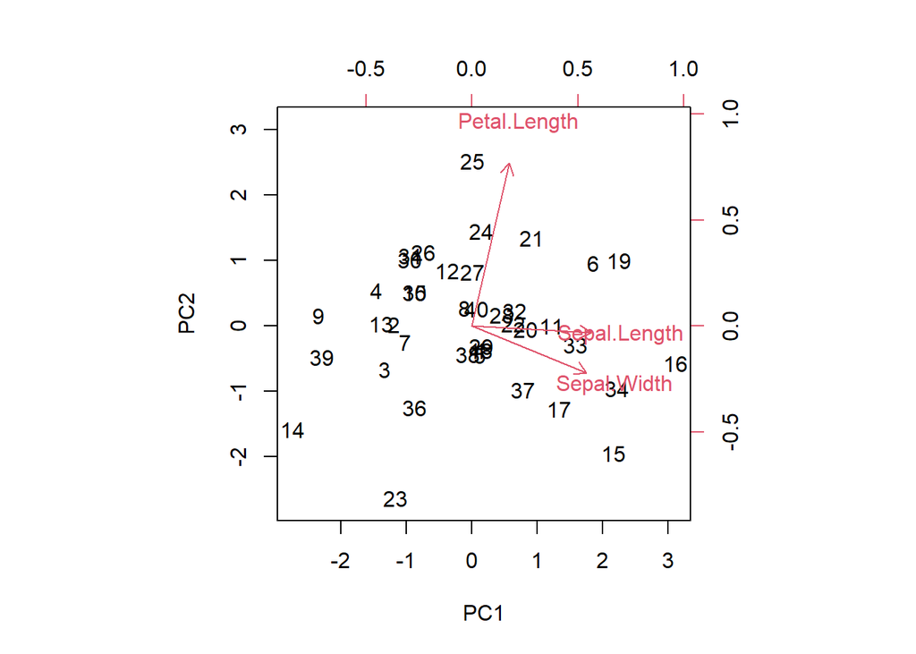

The first focus will be on the upper axis. The upper axis represents the loadings of the variables for PC1. Variable names far to the left or right have a large impact on PC1.

The axis on the right represents the loadings for PC2. Variable names that are high or low on the plot have a large effect on PC2.

Variable names that are grouped together in the same area of the plot are correlated together. From the plot above we can see that sepal length and sepal width are correlated. If there were a variable name that was far to the left we could say it is negatively correlated with sepal length and width.

The bottom axis represents the scores from PC1. Observations with low scores are near the left of the plot while observations with high scores are near the right of the plot.

The left axis represents the scores from PC2. Observations with low scores for PC2 are near the bottom of the plot while observations with high scores of PC2 are near the top of the plot.

Principal components are unique up to the sign. This means if we flip the sign of all our loadings we will get the same conclusions, although the biplot would be flipped and across both the x and y axis. Here is a biplot showing the results if the loadings were assigned negative values to what they are now by chance. (James et al.)

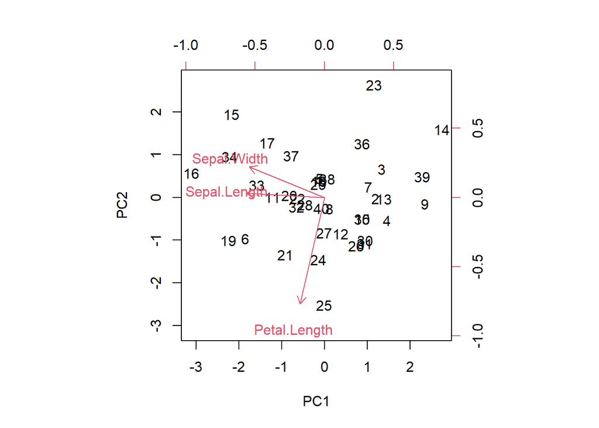

If we go through we will arrive at the same conclusions. Sepal length and sepal width are correlated with each other. Observation 23 displays the smallest petal length.

# Principle Components for Regression (PCR)

After we create our new variables using PCA we can perform regression with a subset of these newly created variables. Ideally, when using PCR a small number of principal components compared to the number of original predictors will account for a large portion of the total variance.

By using a smaller number of PC’s we are able to lower the variance by using a smaller number of variables in our model. However, due to the bias variance trade off this means an increase in the bias of our model.

Thus far we have covered feature selection and normalization techniques we can use to lower the variance in our model. Principal component analysis is not a feature selection technique, as it is possible for the first PC to contain a linear combination of all the predictors. It is a dimension reduction technique as in your model you will be entering less total variables, or dimensions.

The coefficients for PCR are estimated in the ordinary manner, except instead of using the regular observations to build the model, the scores from the PC’s would be used. If a linear regression model was built on all the principal components, meaning all the original information is available, the coefficient estimates would be different, but the predictions made would be the exact same as they would had if a linear regression model was built on the original data.

The number of principal components to use in the linear regression model can be chosen just like a tuning parameter. This means choosing differing number of PC’s, performing cross validation, and choosing the number of PC’s that results in the best MSE. (James et al.)

#### Sources:

Kassambara, A. (2017). Practical guide to principal component methods in R: Pca, (M)Ca, Famd, Mfa, Hcpc, factoextra. Stdha.com.

James, G., Witten, D., Hastie, T., & Tibshirani, R. (n.d.). An introduction to statistical learning: With applications in R.